# Risk Factor Analysis

## Outcome Variable

**Outcome Variable:** stunted

## Predictor Variables

**Intervention Variable:** hhwealth_quart

**Adjustment Set:**

unadjusted

## Stratifying Variables

The analysis was stratified on these variable(s):

- agecat
- studyid
- country

## Data Summary

| agecat | studyid | country | hhwealth_quart | stunted | n_cell | n |
| --- | --- | --- | --- | --- | --- | --- |
| Birth | COHORTS | GUATEMALA | Wealth Q4 | 0 | 278 | 816 |
| Birth | COHORTS | GUATEMALA | Wealth Q4 | 1 | 15 | 816 |
| Birth | COHORTS | GUATEMALA | Wealth Q1 | 0 | 147 | 816 |
| Birth | COHORTS | GUATEMALA | Wealth Q1 | 1 | 10 | 816 |
| Birth | COHORTS | GUATEMALA | Wealth Q2 | 0 | 149 | 816 |
| Birth | COHORTS | GUATEMALA | Wealth Q2 | 1 | 12 | 816 |
| Birth | COHORTS | GUATEMALA | Wealth Q3 | 0 | 195 | 816 |
| Birth | COHORTS | GUATEMALA | Wealth Q3 | 1 | 10 | 816 |
| Birth | COHORTS | PHILIPPINES | Wealth Q4 | 0 | 810 | 3049 |
| Birth | COHORTS | PHILIPPINES | Wealth Q4 | 1 | 32 | 3049 |
| Birth | COHORTS | PHILIPPINES | Wealth Q1 | 0 | 635 | 3049 |
| Birth | COHORTS | PHILIPPINES | Wealth Q1 | 1 | 52 | 3049 |
| Birth | COHORTS | PHILIPPINES | Wealth Q2 | 0 | 500 | 3049 |
| Birth | COHORTS | PHILIPPINES | Wealth Q2 | 1 | 38 | 3049 |
| Birth | COHORTS | PHILIPPINES | Wealth Q3 | 0 | 917 | 3049 |
| Birth | COHORTS | PHILIPPINES | Wealth Q3 | 1 | 65 | 3049 |
| 6 months | COHORTS | GUATEMALA | Wealth Q4 | 0 | 220 | 925 |
| 6 months | COHORTS | GUATEMALA | Wealth Q4 | 1 | 119 | 925 |
| 6 months | COHORTS | GUATEMALA | Wealth Q1 | 0 | 98 | 925 |
| 6 months | COHORTS | GUATEMALA | Wealth Q1 | 1 | 77 | 925 |
| 6 months | COHORTS | GUATEMALA | Wealth Q2 | 0 | 104 | 925 |
| 6 months | COHORTS | GUATEMALA | Wealth Q2 | 1 | 91 | 925 |
| 6 months | COHORTS | GUATEMALA | Wealth Q3 | 0 | 125 | 925 |
| 6 months | COHORTS | GUATEMALA | Wealth Q3 | 1 | 91 | 925 |
| 6 months | COHORTS | PHILIPPINES | Wealth Q4 | 0 | 623 | 2708 |
| 6 months | COHORTS | PHILIPPINES | Wealth Q4 | 1 | 120 | 2708 |
| 6 months | COHORTS | PHILIPPINES | Wealth Q1 | 0 | 431 | 2708 |
| 6 months | COHORTS | PHILIPPINES | Wealth Q1 | 1 | 139 | 2708 |
| 6 months | COHORTS | PHILIPPINES | Wealth Q2 | 0 | 382 | 2708 |
| 6 months | COHORTS | PHILIPPINES | Wealth Q2 | 1 | 103 | 2708 |
| 6 months | COHORTS | PHILIPPINES | Wealth Q3 | 0 | 700 | 2708 |
| 6 months | COHORTS | PHILIPPINES | Wealth Q3 | 1 | 210 | 2708 |
| 24 months | COHORTS | GUATEMALA | Wealth Q4 | 0 | 93 | 1035 |
| 24 months | COHORTS | GUATEMALA | Wealth Q4 | 1 | 309 | 1035 |
| 24 months | COHORTS | GUATEMALA | Wealth Q1 | 0 | 33 | 1035 |
| 24 months | COHORTS | GUATEMALA | Wealth Q1 | 1 | 169 | 1035 |
| 24 months | COHORTS | GUATEMALA | Wealth Q2 | 0 | 39 | 1035 |
| 24 months | COHORTS | GUATEMALA | Wealth Q2 | 1 | 173 | 1035 |
| 24 months | COHORTS | GUATEMALA | Wealth Q3 | 0 | 30 | 1035 |
| 24 months | COHORTS | GUATEMALA | Wealth Q3 | 1 | 189 | 1035 |
| 24 months | COHORTS | PHILIPPINES | Wealth Q4 | 0 | 371 | 2445 |
| 24 months | COHORTS | PHILIPPINES | Wealth Q4 | 1 | 317 | 2445 |
| 24 months | COHORTS | PHILIPPINES | Wealth Q1 | 0 | 139 | 2445 |
| 24 months | COHORTS | PHILIPPINES | Wealth Q1 | 1 | 350 | 2445 |
| 24 months | COHORTS | PHILIPPINES | Wealth Q2 | 0 | 136 | 2445 |
| 24 months | COHORTS | PHILIPPINES | Wealth Q2 | 1 | 287 | 2445 |
| 24 months | COHORTS | PHILIPPINES | Wealth Q3 | 0 | 276 | 2445 |
| 24 months | COHORTS | PHILIPPINES | Wealth Q3 | 1 | 569 | 2445 |

The following strata were considered:

- agecat: 24 months, studyid: COHORTS, country: GUATEMALA
- agecat: 24 months, studyid: COHORTS, country: PHILIPPINES
- agecat: 6 months, studyid: COHORTS, country: GUATEMALA
- agecat: 6 months, studyid: COHORTS, country: PHILIPPINES
- agecat: Birth, studyid: COHORTS, country: GUATEMALA
- agecat: Birth, studyid: COHORTS, country: PHILIPPINES

## Methods Detail

We’re interested in the causal parameters $E[Y_a]$ for all values of $a \in \mathcal{A}$. These parameters represent the mean outcome if, possibly contrary to fact, we intervened to set all units to have $A=a$. Under the randomization and positivity assumptions, these are identified by the statistical parameters $\psi_a=E_W[E_{Y|A,W}(Y|A=a,W)]$. In addition, we’re interested in the mean of $Y$, $E[Y]$ under no intervention (the observed mean). We will estimate these parameters by using SuperLearner to fit the relevant likelihood factors – $E_{Y|A,W}(Y|A=a,W)$ and $p(A=a|W)$, and then updating our likelihood fit using a joint TMLE.

For unadjusted analyses ($W=\{\}$), initial likelihoods were estimated using Lrnr_glm to estimate the simple $E(Y|A)$ and Lrnr_mean to estimate $p(A)$. For adjusted analyses, a small library containing Lrnr_glmnet, Lrnr_xgboost, and Lrnr_mean was used.

Having estimated these parameters, we will then use the delta method to estimate relative risks and attributable risks relative to a prespecified baseline level of $A$.

# Results Detail

## Results Plots

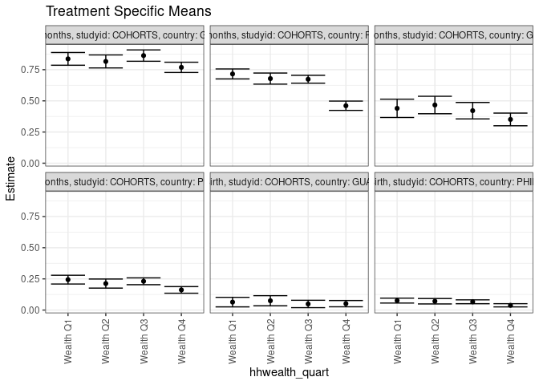

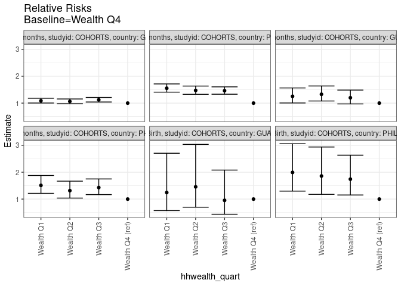

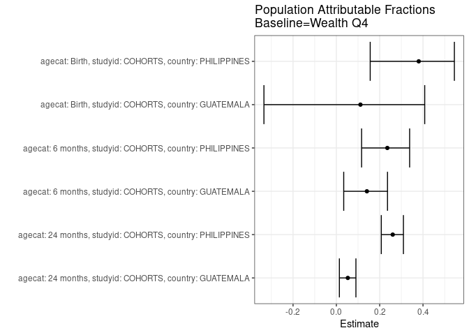

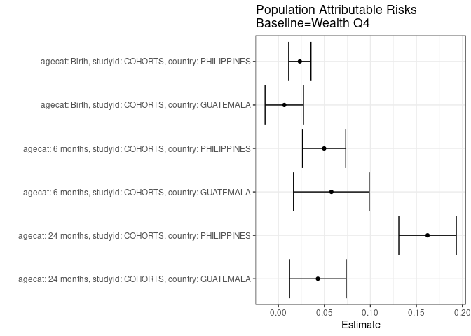

## Results Table

### Parameter: TSM

| agecat | studyid | country | intervention_level | baseline_level | estimate | ci_lower | ci_upper |
| --- | --- | --- | --- | --- | --- | --- | --- |
| Birth | COHORTS | GUATEMALA | Wealth Q4 | NA | 0.0511945 | 0.0259434 | 0.0764457 |
| Birth | COHORTS | GUATEMALA | Wealth Q1 | NA | 0.0636943 | 0.0254714 | 0.1019172 |
| Birth | COHORTS | GUATEMALA | Wealth Q2 | NA | 0.0745342 | 0.0339404 | 0.1151279 |
| Birth | COHORTS | GUATEMALA | Wealth Q3 | NA | 0.0487805 | 0.0192751 | 0.0782858 |
| Birth | COHORTS | PHILIPPINES | Wealth Q4 | NA | 0.0380048 | 0.0250875 | 0.0509220 |
| Birth | COHORTS | PHILIPPINES | Wealth Q1 | NA | 0.0756914 | 0.0559093 | 0.0954735 |
| Birth | COHORTS | PHILIPPINES | Wealth Q2 | NA | 0.0706320 | 0.0489787 | 0.0922852 |
| Birth | COHORTS | PHILIPPINES | Wealth Q3 | NA | 0.0661914 | 0.0506392 | 0.0817437 |
| 6 months | COHORTS | GUATEMALA | Wealth Q4 | NA | 0.3510324 | 0.3001968 | 0.4018681 |
| 6 months | COHORTS | GUATEMALA | Wealth Q1 | NA | 0.4400000 | 0.3664158 | 0.5135842 |
| 6 months | COHORTS | GUATEMALA | Wealth Q2 | NA | 0.4666667 | 0.3966069 | 0.5367264 |
| 6 months | COHORTS | GUATEMALA | Wealth Q3 | NA | 0.4212963 | 0.3554126 | 0.4871800 |
| 6 months | COHORTS | PHILIPPINES | Wealth Q4 | NA | 0.1615074 | 0.1350419 | 0.1879729 |
| 6 months | COHORTS | PHILIPPINES | Wealth Q1 | NA | 0.2438596 | 0.2086013 | 0.2791180 |
| 6 months | COHORTS | PHILIPPINES | Wealth Q2 | NA | 0.2123711 | 0.1759657 | 0.2487765 |
| 6 months | COHORTS | PHILIPPINES | Wealth Q3 | NA | 0.2307692 | 0.2033898 | 0.2581487 |
| 24 months | COHORTS | GUATEMALA | Wealth Q4 | NA | 0.7686567 | 0.7274147 | 0.8098987 |
| 24 months | COHORTS | GUATEMALA | Wealth Q1 | NA | 0.8366337 | 0.7856265 | 0.8876408 |
| 24 months | COHORTS | GUATEMALA | Wealth Q2 | NA | 0.8160377 | 0.7638571 | 0.8682184 |
| 24 months | COHORTS | GUATEMALA | Wealth Q3 | NA | 0.8630137 | 0.8174537 | 0.9085737 |
| 24 months | COHORTS | PHILIPPINES | Wealth Q4 | NA | 0.4607558 | 0.4235020 | 0.4980096 |
| 24 months | COHORTS | PHILIPPINES | Wealth Q1 | NA | 0.7157464 | 0.6757598 | 0.7557331 |
| 24 months | COHORTS | PHILIPPINES | Wealth Q2 | NA | 0.6784870 | 0.6339689 | 0.7230051 |
| 24 months | COHORTS | PHILIPPINES | Wealth Q3 | NA | 0.6733728 | 0.6417455 | 0.7050001 |

### Parameter: E(Y)

| agecat | studyid | country | intervention_level | baseline_level | estimate | ci_lower | ci_upper |
| --- | --- | --- | --- | --- | --- | --- | --- |
| Birth | COHORTS | GUATEMALA | NA | NA | 0.0575980 | 0.0416028 | 0.0735933 |
| Birth | COHORTS | PHILIPPINES | NA | NA | 0.0613316 | 0.0528136 | 0.0698496 |
| 6 months | COHORTS | GUATEMALA | NA | NA | 0.4086486 | 0.3769522 | 0.4403450 |
| 6 months | COHORTS | PHILIPPINES | NA | NA | 0.2112260 | 0.1958496 | 0.2266024 |
| 24 months | COHORTS | GUATEMALA | NA | NA | 0.8115942 | 0.7877598 | 0.8354286 |
| 24 months | COHORTS | PHILIPPINES | NA | NA | 0.6229039 | 0.6036892 | 0.6421186 |

### Parameter: RR

| agecat | studyid | country | intervention_level | baseline_level | estimate | ci_lower | ci_upper |
| --- | --- | --- | --- | --- | --- | --- | --- |
| Birth | COHORTS | GUATEMALA | Wealth Q4 | Wealth Q4 | 1.0000000 | 1.0000000 | 1.000000 |
| Birth | COHORTS | GUATEMALA | Wealth Q1 | Wealth Q4 | 1.2441614 | 0.5721643 | 2.705407 |
| Birth | COHORTS | GUATEMALA | Wealth Q2 | Wealth Q4 | 1.4559006 | 0.6982621 | 3.035603 |
| Birth | COHORTS | GUATEMALA | Wealth Q3 | Wealth Q4 | 0.9528455 | 0.4365830 | 2.079592 |
| Birth | COHORTS | PHILIPPINES | Wealth Q4 | Wealth Q4 | 1.0000000 | 1.0000000 | 1.000000 |
| Birth | COHORTS | PHILIPPINES | Wealth Q1 | Wealth Q4 | 1.9916303 | 1.2971947 | 3.057822 |
| Birth | COHORTS | PHILIPPINES | Wealth Q2 | Wealth Q4 | 1.8585037 | 1.1759273 | 2.937287 |
| Birth | COHORTS | PHILIPPINES | Wealth Q3 | Wealth Q4 | 1.7416624 | 1.1521723 | 2.632756 |
| 6 months | COHORTS | GUATEMALA | Wealth Q4 | Wealth Q4 | 1.0000000 | 1.0000000 | 1.000000 |
| 6 months | COHORTS | GUATEMALA | Wealth Q1 | Wealth Q4 | 1.2534454 | 1.0046826 | 1.563803 |
| 6 months | COHORTS | GUATEMALA | Wealth Q2 | Wealth Q4 | 1.3294118 | 1.0791188 | 1.637758 |
| 6 months | COHORTS | GUATEMALA | Wealth Q3 | Wealth Q4 | 1.2001634 | 0.9697855 | 1.485269 |
| 6 months | COHORTS | PHILIPPINES | Wealth Q4 | Wealth Q4 | 1.0000000 | 1.0000000 | 1.000000 |
| 6 months | COHORTS | PHILIPPINES | Wealth Q1 | Wealth Q4 | 1.5098977 | 1.2135004 | 1.878690 |
| 6 months | COHORTS | PHILIPPINES | Wealth Q2 | Wealth Q4 | 1.3149313 | 1.0373186 | 1.666840 |
| 6 months | COHORTS | PHILIPPINES | Wealth Q3 | Wealth Q4 | 1.4288462 | 1.1671439 | 1.749228 |
| 24 months | COHORTS | GUATEMALA | Wealth Q4 | Wealth Q4 | 1.0000000 | 1.0000000 | 1.000000 |
| 24 months | COHORTS | GUATEMALA | Wealth Q1 | Wealth Q4 | 1.0884360 | 1.0035334 | 1.180522 |
| 24 months | COHORTS | GUATEMALA | Wealth Q2 | Wealth Q4 | 1.0616413 | 0.9766213 | 1.154063 |
| 24 months | COHORTS | GUATEMALA | Wealth Q3 | Wealth Q4 | 1.1227557 | 1.0413466 | 1.210529 |
| 24 months | COHORTS | PHILIPPINES | Wealth Q4 | Wealth Q4 | 1.0000000 | 1.0000000 | 1.000000 |
| 24 months | COHORTS | PHILIPPINES | Wealth Q1 | Wealth Q4 | 1.5534181 | 1.4080141 | 1.713838 |
| 24 months | COHORTS | PHILIPPINES | Wealth Q2 | Wealth Q4 | 1.4725522 | 1.3269324 | 1.634153 |
| 24 months | COHORTS | PHILIPPINES | Wealth Q3 | Wealth Q4 | 1.4614526 | 1.3309925 | 1.604700 |

### Parameter: PAR

| agecat | studyid | country | intervention_level | baseline_level | estimate | ci_lower | ci_upper |
| --- | --- | --- | --- | --- | --- | --- | --- |
| Birth | COHORTS | GUATEMALA | Wealth Q4 | NA | 0.0064035 | -0.0144668 | 0.0272738 |
| Birth | COHORTS | PHILIPPINES | Wealth Q4 | NA | 0.0233268 | 0.0111920 | 0.0354617 |
| 6 months | COHORTS | GUATEMALA | Wealth Q4 | NA | 0.0576162 | 0.0164491 | 0.0987833 |
| 6 months | COHORTS | PHILIPPINES | Wealth Q4 | NA | 0.0497186 | 0.0262132 | 0.0732240 |
| 24 months | COHORTS | GUATEMALA | Wealth Q4 | NA | 0.0429375 | 0.0121527 | 0.0737222 |
| 24 months | COHORTS | PHILIPPINES | Wealth Q4 | NA | 0.1621481 | 0.1309071 | 0.1933890 |

### Parameter: PAF

| agecat | studyid | country | intervention_level | baseline_level | estimate | ci_lower | ci_upper |
| --- | --- | --- | --- | --- | --- | --- | --- |
| Birth | COHORTS | GUATEMALA | Wealth Q4 | NA | 0.1111757 | -0.3344106 | 0.4079718 |
| Birth | COHORTS | PHILIPPINES | Wealth Q4 | NA | 0.3803397 | 0.1562675 | 0.5449044 |
| 6 months | COHORTS | GUATEMALA | Wealth Q4 | NA | 0.1409920 | 0.0339826 | 0.2361476 |
| 6 months | COHORTS | PHILIPPINES | Wealth Q4 | NA | 0.2353810 | 0.1164988 | 0.3382667 |
| 24 months | COHORTS | GUATEMALA | Wealth Q4 | NA | 0.0529051 | 0.0139676 | 0.0903050 |
| 24 months | COHORTS | PHILIPPINES | Wealth Q4 | NA | 0.2603099 | 0.2074321 | 0.3096599 |